# Week5

Sarfaraz Ahmed

August 3, 2017

# Pre-Lab 5: Top Grossing Films

[figure not shown]

Like most Americans, people in Austin are fascinated with cinema. The American film industry has captured the attention of audiences around the world, making film a multibillion-dollar-a-year industry. Most of the top-grossing films of all times have been produced by the same five major studios: 20th-Century Fox, Paramount, Sony Pictures, Universal Pictures and Warner Bros. This data set focuses on the 151 films made by these studios that made the list of the 245 top-grossing films of all times, as determined by source Box Office Mojo. For each of the films, data includes film genre, MPAA rating, measures of film critic and user rankings, and production outcomes such as budget, time in theaters and amount grossed.

Primary Research Questions

1. Does a film’s rating (PG, PG-13, or R) impact its cost to produce?
2. Does a film’s rating (PG, PG-13, or R) influence its IMDB score?

problem 3 points possible (graded) Check the Data

Let’s begin by examining our data in R.

1. Open RStudio. Make sure you’ve installed the SDSFoundations package.
2. Type library(SDSFoundations). This will automatically load the data for the labs. 3.Type film <- FilmData. This will assign the data to your Workspace.
3. Look at the spreadsheet view of the data to answer the following questions.

Alternatively, you can follow the steps in the “Importing a Data Frame” R tutorial video, and use the FilmData.csv file. (Right-click and “Save As.”) Make sure to name the dataframe “film” when importing.

1. Open RStudio.
2. Click on the “Import Dataset” button at the top of the workspace window. Choose “from text file.”
3. Click on the location of the FilmData.csv file you just downloaded.
4. Click on the FilmData.csv file. Then, click Upload.
5. Look at the spreadsheet view of the data to answer the following questions.

```r
library(SDSFoundations)

film <- FilmData
```

1a. What numerical rank does Titanic hold among highest-grossing films?

2 correct2 2 1b. What is the name of the highest ranked film made by Universal Studios? Double-check your spelling before you submit.

Jurassic Park correctJurassic Park 1c. What was the lowest IMDB rating given to a film that ranked in the top 10 grossing films of all time?

6.5 incorrect7.6 6.5 Click here for a video explanation of how to answer this question. Submit You have used 1 of 1 attempt Some problems have options such as save, reset, hints, or show answer. These options follow the Submit button.

Show Answer Answers are displayed within the problem Review problem 6/6 points (graded) Check the Variables of Interest

2a. Which variable tells us whether a film is rated PG, PG-13 or R?

The variable name in the dataset is correctRating , which is a correctcategorical variable.

2b. Which variable tells us the average score the film received on IMDB?

The variable name in the dataset is correctIMDB , which is a correctquantitative variable.

2c. Which variable tells us how much it cost to produce the film?

The variable name in the dataset is correctBudget , which is a correctquantitative variable. Click here for a video explanation of how to answer this question. Submit You have used 1 of 1 attempt Some problems have options such as save, reset, hints, or show answer. These options follow the Submit button.

Show Answer Answers are displayed within the problem Review problem 2/2 points (graded) Reflect on the Method

Which method should we be using for this analysis and why?

3a. We will use ANOVA to help us answer each of these questions. Why?

We want to determine if the category to which a film belongs has an impact on some other quantitative measure. correct We believe the difference in scores given by film critics and IMDB users is significant. We cannot compare the means of these groups using any other method because the groups are related. 3b. We will conduct post-hoc tests, specifically Tukey’s HSD, if the result of either ANOVA is significant. Why?

We want to confirm that the assumptions of ANOVA have been met. We want to locate which group means are different from each other. correct We want to determine the average score for each category.

Primary Research Questions

1. Does a film’s rating (PG, PG-13, or R) impact its cost to produce?
2. Does a film’s rating (PG, PG-13, or R) influence its IMDB score?

Breakdown Your Analysis

Let’s break this analysis into its required steps:

For each ANOVA:

1. Identify the number of films in each rating group (PG, PG-13, R).
2. Compute the mean and standard deviation of the variable of interest for each group.
3. Create boxplots to help visualize group differences and check test assumptions.
4. Run ANOVA.
5. If the F statistic is significant, run a Tukey HSD test to determine which groups are different.

Here is the code you will use:

```r
# Show how many films are in each group
table(film$Rating)
```

```
##
##   PG PG13    R
##   39   94   18
```

Question 1

```r
# Calculate avg film budget of each group
aggregate(Budget~Rating,film,mean)
```

```
##   Rating    Budget
## 1     PG  75.07692
## 2   PG13 127.07447
## 3      R  93.02926
```

```r
# Calculate sd of film budget within each group
aggregate(Budget~Rating,film,sd)
```

```
##   Rating   Budget
## 1     PG 46.46002
## 2   PG13 58.02877
## 3      R 56.90324
```

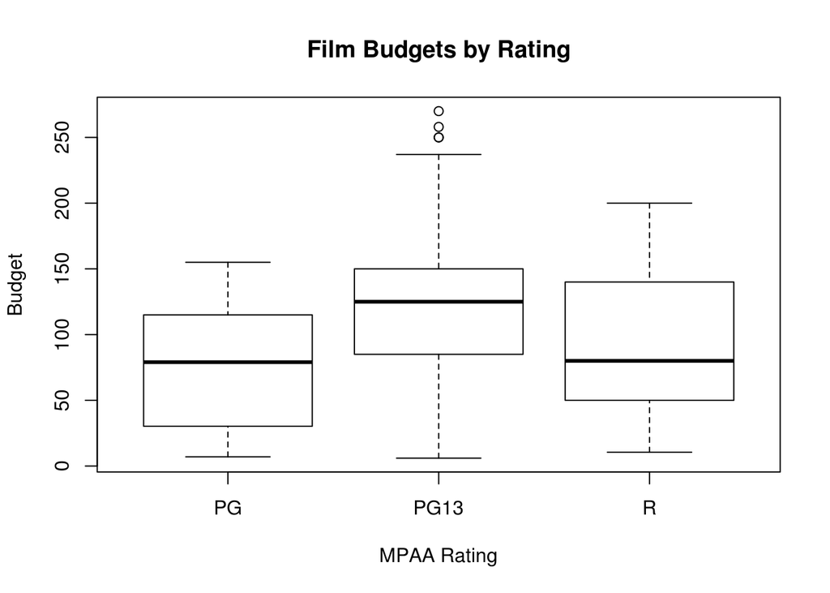

```r
# Visualize the group means and variability
boxplot(film$Budget~film$Rating, main= "Film Budgets by Rating",
ylab= "Budget", xlab= "MPAA Rating")
```

```r
# Run ANOVA
modelbud <- aov(film$Budget~film$Rating)
summary(modelbud)
```

```
##              Df Sum Sq Mean Sq F value   Pr(>F)
## film$Rating   2  79852   39926   13.13 5.67e-06 ***
## Residuals   147 446994    3041
## ---
## Signif. codes:  0 '***' 0.001 '**' 0.01 '*' 0.05 '.' 0.1 ' ' 1
## 1 observation deleted due to missingness
```

```r
# Run post-hoc test if F statistic is significant
TukeyHSD(modelbud)
```

```
##   Tukey multiple comparisons of means
##     95% family-wise confidence level
##
## Fit: aov(formula = film$Budget ~ film$Rating)
##
## $`film$Rating`
##              diff       lwr        upr     p adj
## PG13-PG  51.99755  27.12917 76.8659209 0.0000060
## R-PG     17.95234 -19.99271 55.8973842 0.5031892
## R-PG13  -34.04521 -68.45570  0.3652895 0.0531681
```

Question 2

```r
# Calculate avg IMDB score of each group
aggregate(IMDB~Rating,film,mean)
```

```
##   Rating     IMDB
## 1     PG 7.015385
## 2   PG13 7.014894
## 3      R 7.183333
```

```r
#Calculate sd of IMDB scores within each group
aggregate(IMDB~Rating,film,sd)
```

```
##   Rating      IMDB
## 1     PG 1.0139912
## 2   PG13 0.8213492
## 3      R 0.6679644
```

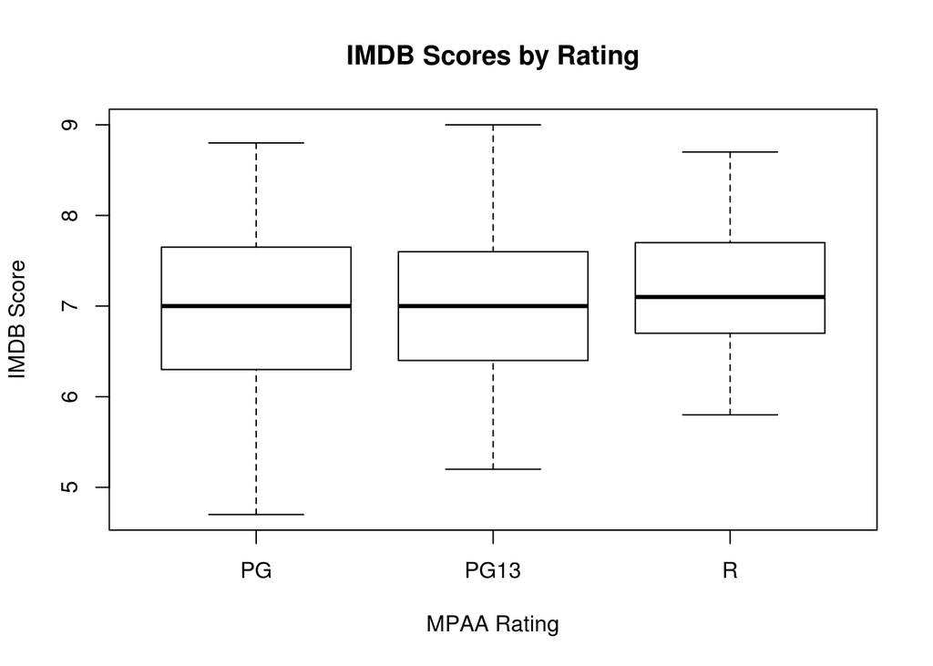

```r
# Visualize the group means and variability
boxplot(film$IMDB~film$Rating, main= "IMDB Scores by Rating",
           ylab= "IMDB Score", xlab= "MPAA Rating")
```

```r
# Run ANOVA
modelscore <- aov(film$IMDB~film$Rating)
summary(modelscore)
```

```
##              Df Sum Sq Mean Sq F value Pr(>F)
## film$Rating   2   0.45  0.2245   0.304  0.738
## Residuals   148 109.39  0.7392
```

```r
# Run post-hod text if F statistic is significant
TukeyHSD(modelscore)
```

```
##   Tukey multiple comparisons of means
##     95% family-wise confidence level
##
## Fit: aov(formula = film$IMDB ~ film$Rating)
##
## $`film$Rating`
##                  diff        lwr       upr     p adj
## PG13-PG -0.0004909984 -0.3881883 0.3872063 0.9999950
## R-PG     0.1679487179 -0.4120567 0.7479541 0.7722832
## R-PG13   0.1684397163 -0.3552476 0.6921270 0.7271492
```

problem 1/1 point (graded) 1. What does aov stand for?

it doesn’t mean anything; it is just an indicator that we want to create a vector of scores an open variable analysis of variance correct Submit You have used 1 of 1 attempt Some problems have options such as save, reset, hints, or show answer. These options follow the Submit button.

Show Answer Correct (1/1 point) Review problem 0/1 point (graded) 2. Which of the following comes closest to what it sounds like to “read aloud” this line of code? `aggregate(Budget~Rating,film,mean)`

Find the Budget for each Rating group, and then calculate the overall mean for the dataset film. incorrect Look across all the Budget cases and then find the mean Rating for each film. For all the cases in film, take the variable Budget and, given the Rating group, find the mean correct Click here for a video explanation of how to answer this question. Submit You have used 1 of 1 attempt Some problems have options such as save, reset, hints, or show answer. These options follow the Submit button.

Show Answer Answers are displayed within the problem Review problem 1/1 point (graded) 3. If group differences are present, what should be true about the output of this line of code? `aggregate(Budget~Rating,film,mean)`

The average budget for each group should be different. correct The mean for the each rating group should be about twice as large as the next. The average rating should appear about the same for each group. Submit You have used 1 of 1 attempt Some problems have options such as save, reset, hints, or show answer. These options follow the Submit button.

Show Answer Correct (1/1 point) Review problem 0/1 point (graded) 4. If we are to satisfy the assumptions of ANOVA, what should be true about the output of this line of code? `aggregate(Budget~Rating,film,sd)`

The standard deviation of each group’s budget should vary. incorrect The largest standard deviation should be no more than twice the smallest standard deviation. correct The standard deviation of each group’s ratings must be identical. Click here for a video explanation of how to answer this question. Submit You have used 1 of 1 attempt Some problems have options such as save, reset, hints, or show answer. These options follow the Submit button.

Show Answer Answers are displayed within the problem Review problem 1/1 point (graded) 5. Suppose we wanted to test if each type of Genre had the same level of Ratings. What has caused the error below? (You may want to refer to the dataset in R for help.)

```r
film <- FilmData
modelRating <- aov(film$Rating~film$Genre)
```

```
## Warning in model.response(mf, "numeric"): using type = "numeric" with a
## factor response will be ignored
```

```
## Warning in Ops.factor(y, z$residuals): '-' not meaningful for factors
```

Warning messages: 1: In model.response(mf, “numeric”) : using type = “numeric” with a factor response will be ignored 2: In Ops.factor(y, z$residuals) : - not meaningful for factors

We should have run a Chi Square Test of Independence. correct We cannot store the aov() function information into “modelRating.” One of the variable names is spelled differently in our dataset. We should have run a two-sample t-test.

Primary Research Questions

1. Does a film’s rating (PG, PG-13, or R) impact its cost?
2. Does a film’s rating (PG, PG-13, or R) influence its IMDB score?

Conduct the Analysis in R

1. Type or copy the script from the Prepare for the Analysis section into the Script window of R.
2. Select the portion of the code you wish to run, then press “ctrl+ enter.”
3. Output can be found in the Console window.

```r
# Show how many films are in each group
table(film$Rating)
```

```
##
##   PG PG13    R
##   39   94   18
```

Question 1

```r
# Calculate avg film budget of each group
aggregate(Budget~Rating,film,mean)
```

```
##   Rating    Budget
## 1     PG  75.07692
## 2   PG13 127.07447
## 3      R  93.02926
```

```r
# Calculate sd of film budget within each group
aggregate(Budget~Rating,film,sd)
```

```
##   Rating   Budget
## 1     PG 46.46002
## 2   PG13 58.02877
## 3      R 56.90324
```

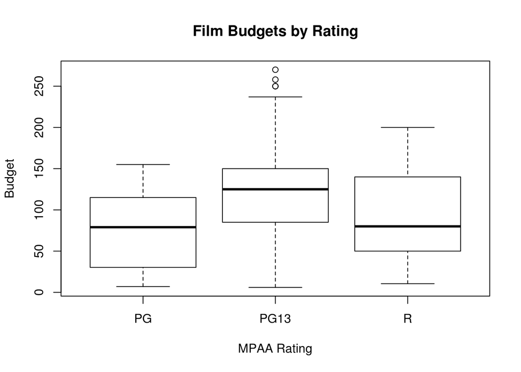

```r
# Visualize the group means and variability
boxplot(film$Budget~film$Rating, main= "Film Budgets by Rating",
ylab= "Budget", xlab= "MPAA Rating")
```

```r
# Run ANOVA
modelbud <- aov(film$Budget~film$Rating)
summary(modelbud)
```

```
##              Df Sum Sq Mean Sq F value   Pr(>F)
## film$Rating   2  79852   39926   13.13 5.67e-06 ***
## Residuals   147 446994    3041
## ---
## Signif. codes:  0 '***' 0.001 '**' 0.01 '*' 0.05 '.' 0.1 ' ' 1
## 1 observation deleted due to missingness
```

```r
# Run post-hoc test if F statistic is significant
TukeyHSD(modelbud)
```

```
##   Tukey multiple comparisons of means
##     95% family-wise confidence level
##
## Fit: aov(formula = film$Budget ~ film$Rating)
##
## $`film$Rating`
##              diff       lwr        upr     p adj
## PG13-PG  51.99755  27.12917 76.8659209 0.0000060
## R-PG     17.95234 -19.99271 55.8973842 0.5031892
## R-PG13  -34.04521 -68.45570  0.3652895 0.0531681
```

Question 2

```r
# Calculate avg IMDB score of each group
aggregate(IMDB~Rating,film,mean)
```

```
##   Rating     IMDB
## 1     PG 7.015385
## 2   PG13 7.014894
## 3      R 7.183333
```

```r
#Calculate sd of IMDB scores within each group
aggregate(IMDB~Rating,film,sd)
```

```
##   Rating      IMDB
## 1     PG 1.0139912
## 2   PG13 0.8213492
## 3      R 0.6679644
```

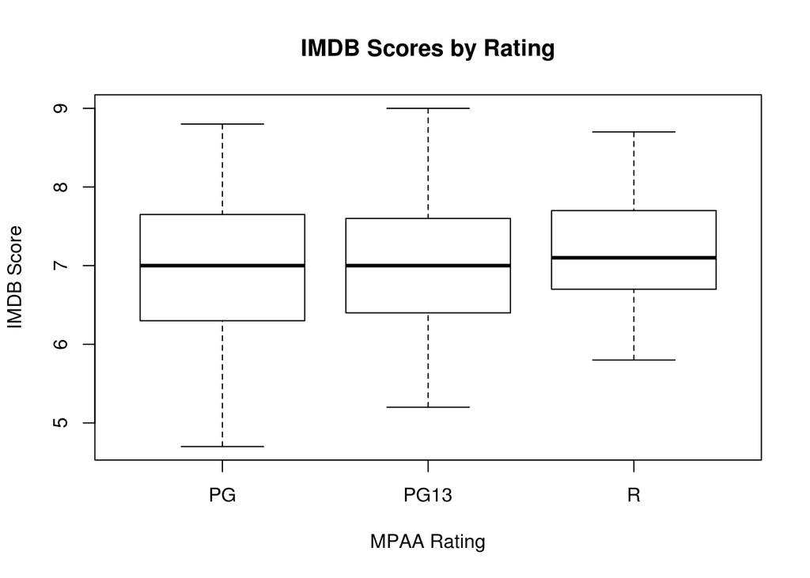

```r
# Visualize the group means and variability
boxplot(film$IMDB~film$Rating, main= "IMDB Scores by Rating",
           ylab= "IMDB Score", xlab= "MPAA Rating")
```

```r
# Run ANOVA
modelscore <- aov(film$IMDB~film$Rating)
summary(modelscore)
```

```
##              Df Sum Sq Mean Sq F value Pr(>F)
## film$Rating   2   0.45  0.2245   0.304  0.738
## Residuals   148 109.39  0.7392
```

```r
# Run post-hod text if F statistic is significant
TukeyHSD(modelscore)
```

```
##   Tukey multiple comparisons of means
##     95% family-wise confidence level
##
## Fit: aov(formula = film$IMDB ~ film$Rating)
##
## $`film$Rating`
##                  diff        lwr       upr     p adj
## PG13-PG -0.0004909984 -0.3881883 0.3872063 0.9999950
## R-PG     0.1679487179 -0.4120567 0.7479541 0.7722832
## R-PG13   0.1684397163 -0.3552476 0.6921270 0.7271492
```

problem 3/3 points (graded) 1a. How many PG-rated films are in the dataset?

39 correct39 39 1b. How many PG-13-rated films are in the dataset?

94 correct94

1c. How many R-rated films are in the dataset

18 correct18

Click here for a video explanation of how to answer this question. Submit You have used 1 of 1 attempt Some problems have options such as save, reset, hints, or show answer. These options follow the Submit button.

Show Answer Answers are displayed within the problem Review problem 7/7 points (graded) Research Question 1

2a. What is the average cost, in millions of dollars, to make each type of film? (no decimal places)

PG=

75 correct75 () PG-13=

127 correct127 () R=

93 correct93 () 2b. Was the assumption of equal variability met?

correctYes ANOVA Results

2c. F-statistic (rounded to one decimal place)=

13.1 correct13.1 () Tukey Test Results

2d. The average budget for a PG-13 film was significantly higher than the budget for a(n) ________ rated film.

PG correctPG 2e. The difference between a PG-13 film and a(n) ________ rated film was almost, but not quite significant, at p = 0.053.

R correctR Click here for a video explanation of how to answer this question. Submit You have used 1 of 1 attempt Some problems have options such as save, reset, hints, or show answer. These options follow the Submit button.

Show Answer Answers are displayed within the problem Review problem 5/5 points (graded) Research Question 2

3a. What is the average IMDB score for each type of film? (Round to 1 decimal place)

PG

7.0 correct7.0 () PG-13

7.0 correct7.0 () R

7.2 correct7.2 () ANOVA Results

3b. What is the F statistic, rounded to 1 decimal place?

0.3 correct0.3 () Tukey Test Results

Was a Tukey test necessary for this analysis? correctNo

problem 7/7 points (graded) Write Your Conclusion

Answer the question and support your answer with statistics:

This analysis examined 151 top-grossing films produced by five major studios. The average cost of a film was found to vary depending on its MPAA rating (F= correct13.1 , p < .05). In a Tukey HSD test, correctPG-13 films were shown to cost significantly more on average ($127M) than PG films ($ correct75 M). PG-13 films fell just shy of costing significantly more than correctR rated films (p=.053). The average IMDB score of a film correctdoes not appear to vary with MPAA rating (F=0.3, p= correct0.74 ). The average ratings for all three categories of film were close to correct7 on a scale of 1-10.

# Lab 5: Top Grossing Films

[figure not shown]

Like most Americans, people in Austin are fascinated with cinema. The American film industry has captured the attention of audiences around the world, making film a multibillion-dollar-a-year industry. Most of the top-grossing films of all times have been produced by the same five major studios: 20th-Century Fox, Paramount, Sony Pictures, Universal Pictures and Warner Bros. This data set focuses on the 151 films made by these studios that made the list of the 245 top-grossing films of all times, as determined by source Box Office Mojo. For each of the films, data includes film genre, MPAA rating, measures of film critic and user rankings, and production outcomes such as budget, time in theaters and amount grossed.

problem 1/2 points (graded) Review of ANOVA

In this lab, you will use ANOVA to answer a question of interest. Let’s start by remembering why we use ANOVA.

1a. What is the goal of an ANOVA analysis?

to determine if significant mean differences exist between multiple groups correct to identify the distribution of counts across three or more groups to compare the variability of scores in two different groups 1b. Two specific group means can be said to be significantly different if:

the F statistic of the overall ANOVA is significant incorrect one group mean is at least twice the value of another a Tukey HSD pairwise comparison shows p < 0.05 (or the identified level of significance) correct Submit You have used 1 of 1 attempt Some problems have options such as save, reset, hints, or show answer. These options follow the Submit button.

Show Answer Answers are displayed within the problem Review problem 1/1 point (graded) Lab Preparation

In this lab you will be working with data from the top grossing films of all time.

1. Open RStudio. Make sure you’ve installed the SDSFoundations package.
2. Type library(SDSFoundations). This will automatically load the data for the labs. 3.Type film <- FilmData. This will assign the data to your Workspace.

Alternatively, you can use the steps in the “Importing a Data Frame” R tutorial video, and use the FilmData.csv file. (Right-click and “Save As.”) Make sure to name the dataframe “film” when importing.

1. Open RStudio.
2. Click on the “Import Dataset” button at the top of the workspace window. Choose “from text file.”
3. Click on the location of the FilmData.csv file you just downloaded.
4. Click on the FilmData.csv file. Then, click Upload.

Feel free to use the script from the week’s PreLab, which you can modify for use in this Lab.

2. Two of the following questions will be answered in this lab using ANOVA. Select the questions that can be answered with this method.

Which studio(s) earn a greater percentage of their earnings domestically? Which studio(s) are more successful in keeping their films in the theaters longer? Which is a better predictor of how much a film will gross: the film’s budget or how long it was in theaters? correct

Primary Research Questions

1. Are some studios more successful in keeping their films in the theaters longer?
2. Do some studios earn a greater percentage of their earnings domestically than others?

Analysis

Let’s break this question down into the different descriptive statistics that you will need to construct your answer. Be sure that your R output includes all of the following components.

For each lab question:

1. Identify the number of films in each studio group.
2. Find the mean and standard deviation of the variable of interest for each group.
3. Create boxplots to help visualize group differences and check test assumptions.
4. Run ANOVA.
5. If the F statistic is significant, run a Tukey HSD test to determine which groups are different.

```r
# Show how many films are in each group
table(film$Studio)
```

```
##
##  Fox Par. Sony Uni.   WB
##   41   24   19   27   40
```

Question 1

```r
# Calculate avg film budget of each group
aggregate(Days~Studio,film,mean)
```

```
##   Studio     Days
## 1    Fox 154.5122
## 2   Par. 142.3750
## 3   Sony 113.7368
## 4   Uni. 130.3704
## 5     WB 145.8500
```

```r
# Calculate sd of film budget within each group
aggregate(Days~Studio,film,sd)
```

```
##   Studio     Days
## 1    Fox 36.18433
## 2   Par. 44.92584
## 3   Sony 28.44652
## 4   Uni. 32.19430
## 5     WB 29.73865
```

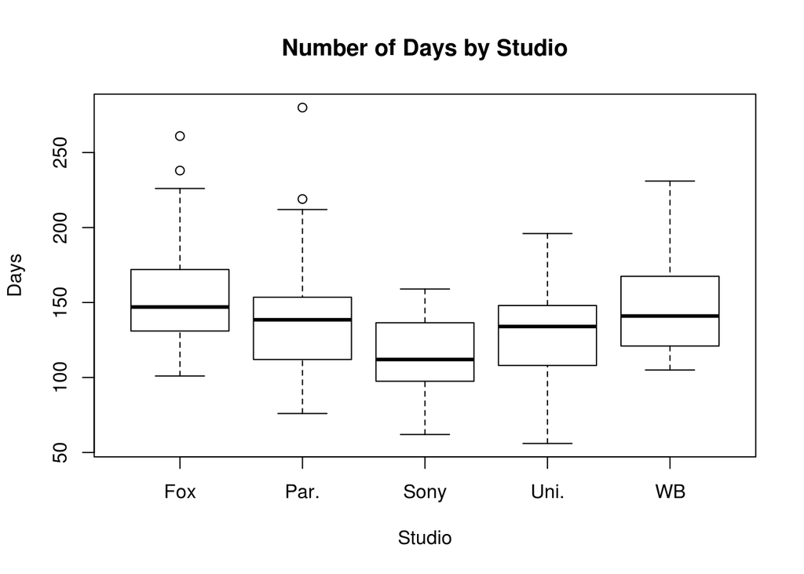

```r
# Visualize the group means and variability
boxplot(film$Days~film$Studio, main= "Number of Days by Studio",
ylab= "Days", xlab= "Studio")
```

```r
# Run ANOVA
model_Days <- aov(film$Days~film$Studio)
summary(model_Days)
```

```
##              Df Sum Sq Mean Sq F value   Pr(>F)
## film$Studio   4  25641    6410   5.354 0.000473 ***
## Residuals   146 174799    1197
## ---
## Signif. codes:  0 '***' 0.001 '**' 0.01 '*' 0.05 '.' 0.1 ' ' 1
```

```r
# Run post-hoc test if F statistic is significant
TukeyHSD(model_Days)
```

```
##   Tukey multiple comparisons of means
##     95% family-wise confidence level
##
## Fit: aov(formula = film$Days ~ film$Studio)
##
## $`film$Studio`
##                 diff        lwr         upr     p adj
## Par.-Fox  -12.137195 -36.701360  12.4269694 0.6510905
## Sony-Fox  -40.775353 -67.300009 -14.2506968 0.0003672
## Uni.-Fox  -24.141825 -47.829559  -0.4540910 0.0434270
## WB-Fox     -8.662195 -29.902632  12.5782422 0.7923196
## Sony-Par. -28.638158 -57.987250   0.7109344 0.0595011
## Uni.-Par. -12.004630 -38.817324  14.8080644 0.7299469
## WB-Par.     3.475000 -21.202277  28.1522771 0.9951088
## Uni.-Sony  16.633528 -11.986042  45.2530981 0.4963966
## WB-Sony    32.113158   5.483715  58.7426006 0.0095337
## WB-Uni.    15.479630  -8.325382  39.2846409 0.3797660
```

Question 2

```r
# Calculate avg IMDB score of each group
aggregate(Pct.Dom~Studio,film,mean)
```

```
##   Studio   Pct.Dom
## 1    Fox 0.4104878
## 2   Par. 0.4342500
## 3   Sony 0.3601053
## 4   Uni. 0.4399259
## 5     WB 0.3956250
```

```r
#Calculate sd of IMDB scores within each group
aggregate(Pct.Dom~Studio,film,sd)
```

```
##   Studio    Pct.Dom
## 1    Fox 0.11437529
## 2   Par. 0.10549562
## 3   Sony 0.09074806
## 4   Uni. 0.11277238
## 5     WB 0.09800044
```

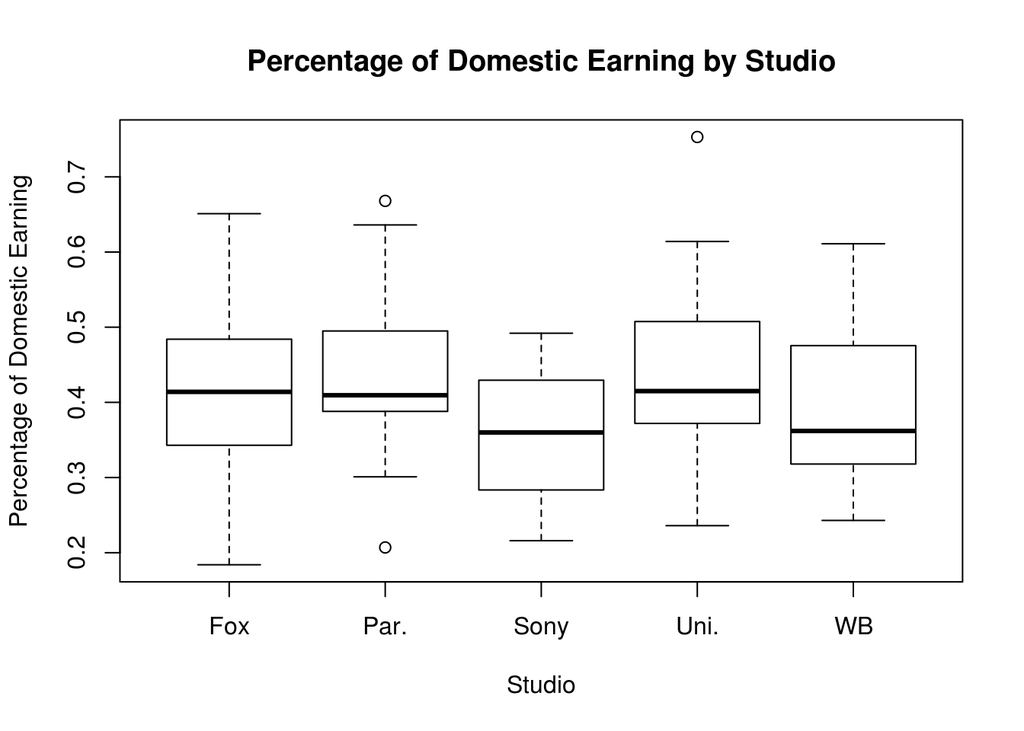

```r
# Visualize the group means and variability
boxplot(film$Pct.Dom~film$Studio, main= "Percentage of Domestic Earning by Studio",
           ylab= "Percentage of Domestic Earning", xlab= "Studio")
```

```r
# Run ANOVA
model_Earnings <- aov(film$Pct.Dom~film$Studio)
summary(model_Earnings)
```

```
##              Df Sum Sq Mean Sq F value Pr(>F)
## film$Studio   4 0.0938 0.02345   2.097 0.0842 .
## Residuals   146 1.6327 0.01118
## ---
## Signif. codes:  0 '***' 0.001 '**' 0.01 '*' 0.05 '.' 0.1 ' ' 1
```

```r
# Run post-hod text if F statistic is significant
TukeyHSD(model_Earnings)
```

```
##   Tukey multiple comparisons of means
##     95% family-wise confidence level
##
## Fit: aov(formula = film$Pct.Dom ~ film$Studio)
##
## $`film$Studio`
##                   diff          lwr        upr     p adj
## Par.-Fox   0.023762195 -0.051311009 0.09883540 0.9059132
## Sony-Fox  -0.050382542 -0.131447418 0.03068233 0.4269583
## Uni.-Fox   0.029438121 -0.042956529 0.10183277 0.7940673
## WB-Fox    -0.014862805 -0.079778007 0.05005240 0.9695769
## Sony-Par. -0.074144737 -0.163841678 0.01555220 0.1562337
## Uni.-Par.  0.005675926 -0.076269253 0.08762111 0.9996976
## WB-Par.   -0.038625000 -0.114043900 0.03679390 0.6192806
## Uni.-Sony  0.079820663 -0.007646705 0.16728803 0.0916247
## WB-Sony    0.035519737 -0.045865388 0.11690486 0.7481975
## WB-Uni.   -0.044300926 -0.117054000 0.02845215 0.4482872
```

Primary Research Questions

1. Are some studios more successful in keeping their films in the theaters longer?
2. Do some studios earn a greater percentage of their earnings domestically than others?

Analysis

Let’s break this question down into the different descriptive statistics that you will need to construct your answer. Be sure that your R output includes all of the following components.

For each lab question:

1. Identify the number of films in each studio group.
2. Find the mean and standard deviation of the variable of interest for each group.
3. Create boxplots to help visualize group differences and check test assumptions.
4. Run ANOVA.
5. If the F statistic is significant, run a Tukey HSD test to determine which groups are different.

problem 5/5 points (graded) The number of top-grossing films produced by each studio were:

1a. Fox

41 correct 41 1b. Paramount

24 correct 24 1c. Sony Pictures

19 correct 19 1d. Universal Studios

27 correct 27 1e. Warner Brothers

40 correct 40 Submit You have used 1 of 1 attempt Some problems have options such as save, reset, hints, or show answer. These options follow the Submit button.

Show Answer Correct (5/5 points) Review problem 4/4 points (graded) Research Question 1

2a. Sony films were in theaters for the shortest period of time. How many days were they in theaters, on average? (round to 1 decimal place)

113.7 correct 113.7 2b. Fox films were in theaters for the longest period of time. How many days were they in theaters, on average? (round to 1 decimal place)

154.5 correct 154.5 ANOVA Results

2c. What was the F statistic for this hypothesis test? (round to 2 decimal places)

5.35 correct 5.35 Tukey Results

2d. We can conclude that _______ films are in theaters longer, on average, than films made by both Sony and Universal.

Fox correct Submit You have used 1 of 1 attempt Some problems have options such as save, reset, hints, or show answer. These options follow the Submit button.

Show Answer Correct (4/4 points) Review problem 4/4 points (graded) Research Question 2

3a. Universal films earned the largest percentage of earnings domestically, with a group mean of _______%. (round to 0 decimal places)

44 correct 44 3b. Sony films earned the smallest percentage of their earnings domestically, with a group mean of _______%. (round to 0 decimal places)

36 correct 36 ANOVA Results

3c. What was the F-statistic for this hypothesis test? (round to 1 decimal place)

2.1 correct 2.1 Tukey Results

3d. How many group means were significantly different from each other?

0 correct 0 Submit You have used 1 of 1 attempt Some problems have options such as save, reset, hints, or show answer. These options follow the Submit button.

Show Answer Correct (4/4 points) Review problem 0/1 point (graded) 4. Which of the following observations allow you to confirm that the distributions were nearly Normal?

The boxplots were not highly skewed. correct The standard deviations of each group were essentially equivalent. incorrect The films in each group were independent of each other.

problem 10/10 points (graded) Write Your Conclusion

Answer the question and support your answer with statistics:

This analysis examined correct151 top-grossing ﬁlms produced by ﬁve major studios. Visual examination of the data through boxplots shows no violation of the approximate equality of correctvariance assumption across the five major studios. Analysis correctrevealed a diﬀerence in the number of days a ﬁlm spent in the theater, by studio (F(4,146)= correct5.354 , p<0.05). In a correctTukey HSD test, correctFox films stayed in the theater significantly longer (155 days) than both correctUniversal (130 days) and Sony Studios (114 days). Sony studios was also significantly lower than correctWarner Brothers studios (146 days).

An additional analysis correctdid not reveal a significant difference in the percentage of earnings domestically, across the five different studios (F(4,146)=2.097, p= correct0.084 .

## Problem Set

Question 1

Do low-budget movies make a different percentage of their profits domestically than movies with medium- or high-budgets?

1. Suppose films with a budget less than $100 Million are considered “low-budget”; films with a budget of $100 million up to but not including 150 Million are considered “medium-budget”, and those with a budget of $150 million or more are “high-budget.”
2. Create a new categorical variable in the dataset that defines each film under these criteria.
3. Use this data to answer the following questions.

Use the “FilmData.csv” dataset to answer the following questions. Instructions for installing “FilmData.csv” can be found under the Examine the Data unit in this week’s Pre-Lab section.

```r
film$BudgetCat[film$Budget < 100] <- "Low-Budget"
film$BudgetCat[film$Budget >= 100 & film$Budget < 150] <- "Medium-Budget"
film$BudgetCat[film$Budget >= 150] <- "High-Budget"

table(film$BudgetCat)
```

```
##
##   High-Budget    Low-Budget Medium-Budget
##            42            67            41
```

```r
aggregate(Pct.Dom~BudgetCat, film, mean)
```

```
##       BudgetCat   Pct.Dom
## 1   High-Budget 0.3758571
## 2    Low-Budget 0.4461940
## 3 Medium-Budget 0.3858293
```

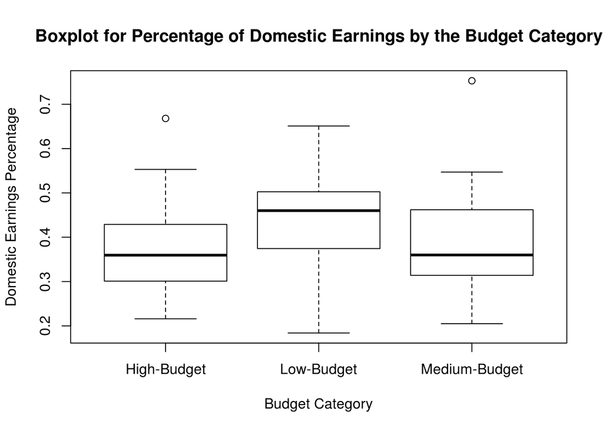

```r
boxplot(film$Pct.Dom~film$BudgetCat, main = "Boxplot for Percentage of Domestic Earnings by the Budget Category",
        xlab = "Budget Category", ylab = "Domestic Earnings Percentage")
```

```r
model_BudgetCat <- aov(film$Pct.Dom ~ film$BudgetCat)

summary(model_BudgetCat)
```

```
##                 Df Sum Sq Mean Sq F value  Pr(>F)
## film$BudgetCat   2 0.1607 0.08034   7.604 0.00072 ***
## Residuals      147 1.5531 0.01057
## ---
## Signif. codes:  0 '***' 0.001 '**' 0.01 '*' 0.05 '.' 0.1 ' ' 1
## 1 observation deleted due to missingness
```

```r
TukeyHSD(model_BudgetCat)
```

```
##   Tukey multiple comparisons of means
##     95% family-wise confidence level
##
## Fit: aov(formula = film$Pct.Dom ~ film$BudgetCat)
##
## $`film$BudgetCat`
##                                   diff         lwr         upr     p adj
## Low-Budget-High-Budget     0.070336887  0.02243871  0.11823507 0.0019196
## Medium-Budget-High-Budget  0.009972125 -0.04345850  0.06340275 0.8980433
## Medium-Budget-Low-Budget  -0.060364762 -0.10862066 -0.01210887 0.0099261
```

problem 1/1 point (graded) 1a. How many films fall into each of the budget categories?

High-Budget Films

42 correct

Submit You have used 1 of 1 attempt Some problems have options such as save, reset, hints, or show answer. These options follow the Submit button.

Show Answer Correct (1/1 point) Review problem 0/1 point (graded) Medium-Budget Films

41 incorrect41

Submit You have used 1 of 1 attempt Some problems have options such as save, reset, hints, or show answer. These options follow the Submit button.

Show Answer problem 1/1 point (graded) Low-Budget Films

67 correct

Submit You have used 1 of 1 attempt Some problems have options such as save, reset, hints, or show answer. These options follow the Submit button.

Show Answer Correct (1/1 point) Review problem 1/1 point (graded) 1b. Calculate the mean percent domestic for each group and enter them below. (Report answers as percentages rounded to one decimal place.)

High-Budget Films

37.6 correct () Submit You have used 1 of 1 attempt Some problems have options such as save, reset, hints, or show answer. These options follow the Submit button.

Show Answer Correct (1/1 point) Review problem 1/1 point (graded) Medium-Budget Films

38.6 correct () Submit You have used 1 of 1 attempt Some problems have options such as save, reset, hints, or show answer. These options follow the Submit button.

Show Answer Correct (1/1 point) Review problem 1/1 point (graded) Low-Budget Films

44.6 correct () Submit You have used 1 of 1 attempt Some problems have options such as save, reset, hints, or show answer. These options follow the Submit button.

Show Answer Correct (1/1 point) Review Create a boxplot to check the assumptions of ANOVA. Then run an ANOVA and report your findings below.

problem 1/1 point (graded) 1c. What is the F-statistic for this test? (Round to 1 decimal place.)

7.6 correct () Submit You have used 1 of 1 attempt Some problems have options such as save, reset, hints, or show answer. These options follow the Submit button.

Show Answer Correct (1/1 point) Review problem 1/1 point (graded) 1d. What are the degrees of freedom?

Numerator Degree of Freedom

2 correct () Submit You have used 1 of 1 attempt Some problems have options such as save, reset, hints, or show answer. These options follow the Submit button.

Show Answer Correct (1/1 point) Review problem 1/1 point (graded) Denominator Degree of Freedom

147 correct () Submit You have used 1 of 1 attempt Some problems have options such as save, reset, hints, or show answer. These options follow the Submit button.

Show Answer Correct (1/1 point) Review problem 1/1 point (graded) 1e. What is the p-value of the test? (Round to 3 decimal places.)

0.001 correct () Submit You have used 1 of 1 attempt Some problems have options such as save, reset, hints, or show answer. These options follow the Submit button.

Show Answer Correct (1/1 point) Review problem 1/1 point (graded) 1f. What is the appropriate conclusion for this test?

The mean percent gross earned domestically is equal across all budget groups. The mean percent gross earned domestically is NOT equal across all budget groups. correct Submit You have used 1 of 1 attempt Some problems have options such as save, reset, hints, or show answer. These options follow the Submit button.

Show Answer Correct (1/1 point) Review problem 1/1 point (graded) 1g. Run a Tukey HSD post-hoc analysis and chose the correct adjusted p-values for each pairwise comparison listed below.

Low vs. High

correct Submit You have used 1 of 1 attempt Some problems have options such as save, reset, hints, or show answer. These options follow the Submit button.

Show Answer Correct (1/1 point) Review problem 1/1 point (graded) Low vs. Medium

correct Submit You have used 1 of 1 attempt Some problems have options such as save, reset, hints, or show answer. These options follow the Submit button.

Show Answer Correct (1/1 point) Review problem 0/1 point (graded) Medium vs. High

incorrect0.898 Submit You have used 1 of 1 attempt Some problems have options such as save, reset, hints, or show answer. These options follow the Submit button.

Show Answer Answers are displayed within the problem Review problem 1/1 point (graded) 1h. What is the appropriate conclusion for the post-hoc analysis?

Both low-budget and medium-budget films earn a greater percentage of their profit domestically than high-budget films. High-budget films earn a greater percentage of their profit domestically than either low-budget or high-budget films. Medium-budget films earn the most percentage of their profit domestically. Low-budget films earn a greater percentage of their profit domestically than either medium-budget or high-budget films. correct

Question 2

Forty-five (45) dog lovers are recruited for a study examining the calming effects of pets during stressful situations.

Fifteen (15) subjects were randomly assigned to each of three different groups:

- performing the task alone (control),
- performing the task with a good friend present, and
- performing the task with their dog present.

The peak heart rate (in beats per minute) during the task was measured for each subject, with the following results:

Alone Good Friend Pet Dog Mean 82.52 91.32 73.48 SD 9.24 8.34 9.97

problem 1/1 point (graded) 2a. What is the appropriate null hypothesis for this test?

H0:μ1=μ2=μ3 correct H0:μ1≠μ2≠μ3 H0:μ1≠μ2=μ3 Submit You have used 1 of 1 attempt Some problems have options such as save, reset, hints, or show answer. These options follow the Submit button.

Show Answer Correct (1/1 point) Review problem 1/1 point (graded) 2b. To run a reliable ANOVA, what must be true of this data?

The heart rate data should be normally distributed in each group. Each group should have approximately equal standard deviations. Each group has independent, random data. All of the above. correct Submit You have used 1 of 1 attempt Some problems have options such as save, reset, hints, or show answer. These options follow the Submit button.

Show Answer Correct (1/1 point) Review problem 1/1 point (graded) 2c. What are the degrees of freedom for this test?

Numerator Degree of Freedom

2 correct 2 Submit You have used 1 of 1 attempt Some problems have options such as save, reset, hints, or show answer. These options follow the Submit button.

Show Answer Correct (1/1 point) Review problem 1/1 point (graded) Denominator Degree of Freedom

42 correct 42 Submit You have used 1 of 1 attempt Some problems have options such as save, reset, hints, or show answer. These options follow the Submit button.

Show Answer Correct (1/1 point) Review problem 1/1 point (graded) 2d. What is the critical F for this test, assuming α= 0.05? (Round to 2 decimal places.)

3.22 correct 3.22 Submit You have used 1 of 1 attempt Some problems have options such as save, reset, hints, or show answer. These options follow the Submit button.

Show Answer Correct (1/1 point) Review problem 0/1 point (graded) 2e. In this problem, you find that SStotal = 5949.1 and SSBetween = 2387.7. What is the F statistic for the test? (Round to 2 decimal places.)

52.41 incorrect14.08 52.41 Submit You have used 1 of 1 attempt Some problems have options such as save, reset, hints, or show answer. These options follow the Submit button.

Show Answer Answers are displayed within the problem Review problem 1/1 point (graded) 2f. What is the outcome of this test?

Fail to reject the null hypothesis Reject the null hypothesis correct

Question 3

A local police department has divided the city into three sections, and each is patrolled by a different set of six (6) officers. The police chief wants to determine if officers are biased in the number of disorderly conduct tickets that they give out in each section.

Here are the number of tickets given by the officers in each section in the last week:

Section 1 Section 2 Section 3 8 3 1 4 7 2 6 0 7 8 2 6 6 7 5 4 5 0

```r
Q3 <- data.frame(Tickets = c(8, 4, 6, 8, 6, 4, 3, 7, 0, 2, 7, 5, 1, 2, 7, 6, 5, 0), Section = c(rep("Section1", 6), rep("Section2", 6), rep("Section3", 6)))
Q3
```

```
##    Tickets  Section
## 1        8 Section1
## 2        4 Section1
## 3        6 Section1
## 4        8 Section1
## 5        6 Section1
## 6        4 Section1
## 7        3 Section2
## 8        7 Section2
## 9        0 Section2
## 10       2 Section2
## 11       7 Section2
## 12       5 Section2
## 13       1 Section3
## 14       2 Section3
## 15       7 Section3
## 16       6 Section3
## 17       5 Section3
## 18       0 Section3
```

```r
model_Q3 <- aov(Q3$Tickets~Q3$Section)
summary(model_Q3)
```

```
##             Df Sum Sq Mean Sq F value Pr(>F)
## Q3$Section   2   21.0    10.5   1.615  0.232
## Residuals   15   97.5     6.5
```

problem 1/1 point (graded) 3a. Which of the following is the alternative hypothesis for this test?

HA: Police officers in at least one section of the city give out a different number of ￼tickets on average. correct HA: Police officers in at least two sections of the city give out a different number of ￼tickets on average than the third. HA: The average number of tickets handed out are equal across the three sections of the city. Submit You have used 1 of 1 attempt Some problems have options such as save, reset, hints, or show answer. These options follow the Submit button.

Show Answer Correct (1/1 point) Review problem 1/1 point (graded) 3b. What are the degrees of freedom for this problem?

Numerator Degree of Freedom

2 correct 2 Submit You have used 1 of 1 attempt Some problems have options such as save, reset, hints, or show answer. These options follow the Submit button.

Show Answer Correct (1/1 point) Review problem 1/1 point (graded) Denominator Degree of Freedom

15 correct 15 Submit You have used 1 of 1 attempt Some problems have options such as save, reset, hints, or show answer. These options follow the Submit button.

Show Answer Correct (1/1 point) Review problem 0/1 point (graded) 3c. What is SSTotal for this problem? (Round to 1 decimal place.)

21.0 incorrect118.5 21.0 Submit You have used 1 of 1 attempt Some problems have options such as save, reset, hints, or show answer. These options follow the Submit button.

Show Answer Answers are displayed within the problem Review problem 0/1 point (graded) 3d. What is MSBetween for this problem? (Round to 1 decimal place.)

21.0 incorrect10.5 21.0 Submit You have used 1 of 1 attempt Some problems have options such as save, reset, hints, or show answer. These options follow the Submit button.

Show Answer Answers are displayed within the problem Review problem 1/1 point (graded) 3e. What is MSWithin for this problem? (Round to 1 decimal place.)

6.5 correct 6.5 Submit You have used 1 of 1 attempt Some problems have options such as save, reset, hints, or show answer. These options follow the Submit button.

Show Answer Correct (1/1 point) Review problem 1/1 point (graded) 3f. What is the F statistic for this test? (Round to 3 decimal places.)

1.615 correct () Submit You have used 1 of 1 attempt Some problems have options such as save, reset, hints, or show answer. These options follow the Submit button.

Show Answer Correct (1/1 point) Review problem 1/1 point (graded) 3g. What is the appropriate conclusion for this test?

Because our Null Hypothesis is Rejected, there is evidence to suggest that police officers are giving out a different number of tickets in these three sections, on average. There is NO evidence to suggest that police officers are giving out a different number of tickets in these three sections, on average. correct Police officers in at least two sections of the city are giving out a different number of ￼tickets on average than the third.

Question 4

Below is the source table for a study on sleep aids, comparing the effectiveness of three (3) different treatments. Note that some of the elements of the table are missing.

SS df MS F Between Treatments 782.00  
Within Treatments 34  
Total 2,147.00  
problem 1/1 point (graded) 4a. What is SSWithin ?

1365 correct () Submit You have used 1 of 1 attempt Some problems have options such as save, reset, hints, or show answer. These options follow the Submit button.

Show Answer Correct (1/1 point) Review problem 1/1 point (graded) 4b. What is dfTotal ?

36 correct () Submit You have used 1 of 1 attempt Some problems have options such as save, reset, hints, or show answer. These options follow the Submit button.

Show Answer Correct (1/1 point) Review problem 1/1 point (graded) 4c. What is MSWithin ? (Round to 2 decimal places.)

40.15 correct () Submit You have used 1 of 1 attempt Some problems have options such as save, reset, hints, or show answer. These options follow the Submit button.

Show Answer Correct (1/1 point) Review problem 1/1 point (graded) 4d. What is the F statistic? (Round to 2 decimal places, and use your rounded answer from 4c.)

9.74 correct () Submit You have used 1 of 1 attempt Some problems have options such as save, reset, hints, or show answer. These options follow the Submit button.

Show Answer Correct (1/1 point) Review problem 1/1 point (graded) 4e. Using an F-critical of 3.28, what is the appropriate conclusion of the test?

At least one of the sleep aids performs better than the others. correct The three sleep aids perform equally well. Submit You have used 1 of 1 attempt Some problems have options such as save, reset, hints, or show answer. These options follow the Submit button.

Show Answer Correct (1/1 point) Review problem 1/1 point (graded) 4f. You decide to perform a post-hoc analysis on these group means using a Bonferroni correction. How many group mean comparisons will you do?

3 correct () Submit You have used 1 of 1 attempt Some problems have options such as save, reset, hints, or show answer. These options follow the Submit button.

Show Answer Correct (1/1 point) Review problem 0/1 point (graded) 4g. What should be the new significance level for your post-hoc tests, assuming an original α=0.05? (Round to 3 decimal places.)

0.143 incorrect0.017 () Submit You have used 1 of 1 attempt Some problems have options such as save, reset, hints, or show answer. These options follow the Submit button.

Show Answer Answers are displayed within the problem Review 4h. Here are the results from your post-hoc analysis. These are the p-values from the actual t-tests. They are not adjusted, so be sure to compare them to the significance level you calculated above.

T-Statistic P-Value Group 1 - Group 2 1.90 0.137 Group 1 - Group 3 3.79 0.004 Group 2 - Group 3 3.44 0.028

problem 1/1 point (graded) What do you conclude?

The Sleep Aid 1 group and Sleep Aid 2 group were significantly different from Sleep Aid 3 group, but not from each other. The Sleep Aid 1 group and Sleep Aid 2 group were significantly different from one another. The Sleep Aid 1 was significantly different from the Sleep Aid 3 group. correct